# Assignment 5

## Topic: VC-Dimension

## Machine Learning: Theoretical Concepts, SS 2019

### Deadline May 8th 2019, 24:00

Return this notebook with your code and answers.

# Exercise A

### Question 5.1 (10+15 Points)

In this question you are asked to compute the VC-dimension of certain hypotheses classes on the real line $\mathbb{R}$. No completely rigorous proofs are necessary, a rough verbal description is perfectly fine; it also might be a good idea to assist your claims with graphical arguments, i.e. by uploading pictures of your sketches to your notebooks (or producing them in Latex or Python). By doing so, argue that:

- The VC-dimension of the hypothesis class of intervals is $2$.
- The VC-dimension of the hypothesis class of unions of $k$ intervals is $2k$.
- **TODO:** Markdown, Latex

### Answer 5.1:

- **The VC-dimension of the hypothesis class of intervals is $2$**

For $0$ and $1$ points this holds trivially.

We classify a point $x$ as $1$ $\iff$ $\exists a, b | a < x < b$ with $x \in \mathbb{R}$.

We classify a point as $0$ if it is outside this interval.

For $x_1 < x_2$ we get the following intervalls

| labeling | $x_1$ | $x_2$ | possible interval |
| --- | --- | --- | --- |
| 1 | 0 | 0 | $(x_1, x_2)$ |
| 2 | 0 | 1 | $(x_1, \infty)$ |
| 3 | 1 | 0 | $(-\infty, x_2)$ |
| 4 | 1 | 1 | $(-\infty, \infty)$ |

For three points however, this is no longer possible

| labeling | $x_1$ | $x_2$ | $x_3$ | possible interval |
| --- | --- | --- | --- | --- |
| 1 | 0 | 0 | 0 | $(x_3, \infty)$ |
| 2 | 0 | 0 | 1 | $(x_2, \infty)$ |
| 3 | 0 | 1 | 0 | $(x_1, x_3)$ |
| 4 | 0 | 1 | 1 | $(x_1, \infty)$ |
| 5 | 1 | 0 | 0 | $(-\infty, x_2)$ |
| 6 | 1 | 0 | 1 | impossible |
| 7 | 1 | 1 | 0 | $(-\infty, x_3)$ |
| 8 | 1 | 1 | 1 | $(-\infty, \infty)$ |

Thus we see that the $VC_{dim}$ of intervals is $2$.

- **The VC-dimension of the hypothesis class of unions of $k$ intervals is 2$k$.**

Assuming that all intervalls are well ordered and do not overlap we could (in the worst case) end up with alternating $10$ labels (in regex syntax: $(1^+0^+)^k$ *one or more $1$ followed by one or more $0$, repeated $k$ times*).

Then we can iteratively split one label series of either $1$s or $0$s from the union. Since there are $2$ series per set over $k$ sets in total, at worst there are $2k$ splits necessary.

Thus the $VC_{dim}$ of $k$ unions of intervals is $2k$.

### Question 5.2 (15+15+15 Points)

In this question we are now investigating the situation on the plane $\mathbb{R}^2$ for certain hypothesis families. Again, no completely rigorous proofs are necessary, a rough verbal description is perfectly fine; it also might be a good idea to assist your claims with graphical arguments, i.e. by uploading pictures of your sketches to your notebooks (or producing them in Latex or Python). By doing so, argue that:

- The VC-dimension of the hypothesis class of axis aligned rectangles is $4$.
- The VC-dimension of the hypothesis class of axis aligned squares is $3$.
- The VC-dimension of the hypothesis class of general triangles is greater or equal than $7$ (it is in fact $=7$, but this is harder to prove and requires some more advanced geometric arguments). (Hint: consider $7$ points lying on a circle and distinguish the cases where there are more positive than negative labels vs. the other way round.)
- **TODO:** Markdown, Latex

### Answer 5.2:

For each of the answers, we need to prove the following:

- It is possible to shatter all $2^n$-possible label encodings
- It is not possible to shatter all $2^{n+1}$ label encodings

(In all the subsequent drawings the points are supposed to be directly on the border not slightly off (except for the points clearly within the bounding polygon)

### The VC-dimension of the hypothesis class of axis aligned rectangles is 4

[figure not shown]

The minimum bounding box for 4 points in 2-dimensional space is a rectancle. We can reduce the width and length of the rectancle (and even move it) to exclude any subset of points.

Thus we have shown, that $VC_{dim}(Rectangle) \ge 4$

[figure not shown]

It is, however, not possibly to exclude just the blue point from the bounding rectangle. It can be shown for every axis-aligned rectangle, that we can construct a *blue* point that lies within the bounding box of the rectangle.

### The VC-dimension of the hypothesis class of axis aligned squares is $3$

[figure not shown]

The minimum bounding box for 3 points in two dimensional space is a square, which we can move to exclude any subset of points.

Thus we have shown, that $VC_{dim}(Square) \ge 3$

[figure not shown]

Analogously to above we cannot, however, exclude just the blue point, showing that $VC_{dim}(Square) \not> 3$, thus proving that $VC_{dim}(Square) = 3$

### The VC-dimension of the hypothesis class of general triangles is greater or equal than $7$

If there are 7 points distributed on a circle, at worst there are 3 contiguous blocks of *negative* labels (we can define the smaller set of labels (minority) as negative and show that there is a triangle that includes these 3 and **JUST** these 3 contiguous blocks: like $\{+, -, +, -, +, -, +\}$)

For the alternatig case of $\{+, -, +, -, +, -, +\}$ all we have to do is find a triangle, that is bounded by the circle, where each corner "touches" one of the *negative* labels like this:

[figure not shown]

This way of constructing the triangle holds for less than 3 contiguous blocks of 3 negative labels as well:

[figure not shown]

For fewer than 3 negative labels just choose an arbitrary point within the circle (**not** on its circumference) to construct the triangle like this:

[figure not shown]

Thus, we have shown that $VC_{dim}(Triangle) \ge 7$

If we were to show it for 8 points, we would see that the argument from above would fail to work, since now in the worst case we would have 4 contiguous blocks of labels $\{+, -, +, -, +, -, +, -\}$, which would require an extra corner to cover, thus creating a polygon and not a triangle.

Thus, we have shown that $VC_{dim}(Triangle) \not> 7$, implying $VC_{dim}(Triangle) = 7$

The exercises should convince you about the following observations: first, simple figures, which at first sight look very similar geometrically, might lead to different properties concerning their abilities of separating data(like squares, rectangles and triangles). Secondly, if the complexity of the separating class gets higher, then this usually also leads to better separation properties as indicated in the first example. Even the number of parameters that characterize the hypothesis class is not an indicator for it's VC-dimension: in the lecture even an example of a one-parameter family with infinite VC-dimension was mentioned.

# Exercise B

In this exercise, a programming example should further strenghen your intuition about how model complexity affects the performance of a classifier and how this is related to its VC-dimension.

### Question 5.3 (10 Points)

First of all we want to create binary labelled data on the unit circle. Therefore implement a function "create_data" that depends on a parameter $k\in \mathbb{N} \geq 2$, which returns $k$-labeled data drawn uniformly from the unit circle with binary labels contained in $\{-1,1\}$, such that the points in the upper half of the circle should be labeled with $1$, and points in the lower half by $-1$. We provide the code for the first two data points, which we label with $+1$ and $-1$ respectively(The reason for this is, that we need to guarantee at least two different labels for the upcoming tasks. Keep in mind that we label them randomly, no matter where they lie in the plane. For creating further points you should proceed differently!). You should now finish the code according to the description above. Hint: to understand the procedure for the first two points, recall that points in the unit circle can be written as $\left( r \cos(\varphi), r \sin(\varphi) \right)$, where $0\le r \le 1$ and $0 \le \varphi \le 2 \pi$.

- **TODO:** Code

Next we want to implement a linear support-vector classifier(SVC) that separates the data "as accurately as possible", using a separating hyperplane(in our case: a straight line, as we are considering the situation in the plane). What we want to achieve in the end is that the separating line's distance from the data should be as large as possible(indicated by a large so called "margin"), so that also test data can be classified as accurately as possible. As this usually isn't possible in general situations (e.g. when a lot of randomness is present in the data), certain variables, that don't exactly fit in this framework have to be "punished" using so called slack-variables. It might e.g. be allowed for a certain amount of points to lie inside the margin or lie on the wrong side of the borders. This procedure in many situations can improve the generalization performance of the classifier. In any case, we won't go into the details here, and just mention that the amount of this "punishment" is encoded in the hyperparameter $C$ for the SVC. For further information consult e.g. the lecture notes for the supervised learning course.

We provide the code for the implementation of the SVC using the sklearn-toolkit. Also a function, that outputs the margin for a SVM classifier is provided. For more details, consult https://scikit-learn.org/stable/modules/generated/sklearn.svm.SVC.html#sklearn.svm.SVC . Your task is now the following:

### Question 5.4 (10 Points)

Write a function "compute_svm" that again depends on a parameter $k\in \mathbb{N} \geq 10$, and that computes linear SVCs for up to $k$ data points created via the "create_data" function using a for-loop. For each number of data points the corresponding margin should be printed and stored in a list. So in the end for each $10 \le j \le k$ a different SVC for $j$ data distributed according to the procedure from the previous question should be computed and the corresponding margin should be stored. The output of the function should be the list containing the margins. Run compute_svm(1000) and store the outputted list. The code for computing the SVC and its margin for a fixed number of data is provided.

- **TODO:** Code

### Question 5.5 (10 Points)

Now we want to relate the behavior of the margin to theoretical results concerning the VC-dimension: It holds, that for data which lie in a ball of radius $R$, the VC-dimension $d_{VC}$ of a linear support-vector classifier with margin $\gamma$ is bounded by $d_{VC} \le \frac{R^2}{\gamma^2}$(cf. page 63 in the lecture notes). Using this fact, visualize the dependence of the margin and the VC dimension on the number of data points in two separate plots, using the previously produced list of margin values. Remember that all our data are contained in the unit circle.

- **TODO:** Code

```python
# Some code that should help you. Nothing to do here
import sklearn as sk
import numpy as np
import matplotlib.pyplot as plt
from sklearn import svm
# Create empty list that should store feature values.
x = []
# Create empty list that should store labels.
y = []
# Randomly create one point on unit circle with label y=1, store features and labels in the corresponding lists.
length_1 = np.random.uniform(0, 1)
angle_1 = np.pi * np.random.uniform(0, 2)
x.append(
    [np.sqrt(length_1) * np.cos(angle_1),
     np.sqrt(length_1) * np.sin(angle_1)])
y.append(1)

#Randomly create another point on unit circle with label y=-1, store features and labels it in the corresponding lists.
length_2 = np.random.uniform(0, 1)
angle_2 = np.pi * np.random.uniform(0, 2)
x.append(
    [np.sqrt(length_2) * np.cos(angle_2),
     np.sqrt(length_2) * np.sin(angle_2)])
y.append(-1)
print(x, y)

#Code for linear SVC containing only the previously created points as data, also outputs corresponding margin.
clf = svm.SVC(kernel='linear', C=1)
clf.fit(x, y)
margin = 1 / np.linalg.norm(clf.coef_)
print(margin)
```

```
[[0.3305982230526665, 0.46763494617236756], [0.19366106956563925, -0.915143104995517]] [1, -1]
0.719661595088498
```

### Answer 5.3, 5.4 and 5.5:

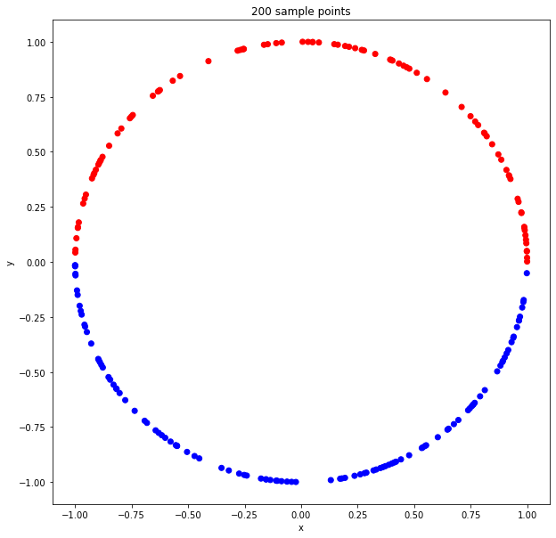

```python
def k_circle_points(k):
    data = []
    for i in range(k):
        angle = np.pi * np.random.uniform(high=2)
        data.append((np.cos(angle), np.sin(angle)))
    data = np.asarray(data)
    return data, (data[:, 1] > 0).astype(int)

X, y = k_circle_points(200)
plt.figure(figsize=(10, 10))
plt.scatter(X[:, 0], X[:, 1], c=[['blue', 'red'][y_i] for y_i in y])
plt.xlabel('x')
plt.ylabel('y')
plt.title('200 sample points')
plt.show()
```

```python
def compute_svm(k):
    if k <= 10:
        raise ValueError(f'k needs to be >= 10; but was: {k}')

    clf = svm.SVC(kernel='linear')
    margins = []
    for j in range(10, k + 1):
        X, y = k_circle_points(j)
        clf.fit(X, y)
        margins.append(1 / np.linalg.norm(clf.coef_))

    return margins

marg = np.asarray(compute_svm(1000))
print(f'First 5: {marg[:5]}')
print('...')
print(f'Last 5: {marg[-5:]}')
```

```
First 5: [0.82775222 0.68632089 0.55478568 0.72535749 0.66488816]
...
Last 5: [0.14376195 0.14824891 0.14473944 0.15059736 0.14963801]
```

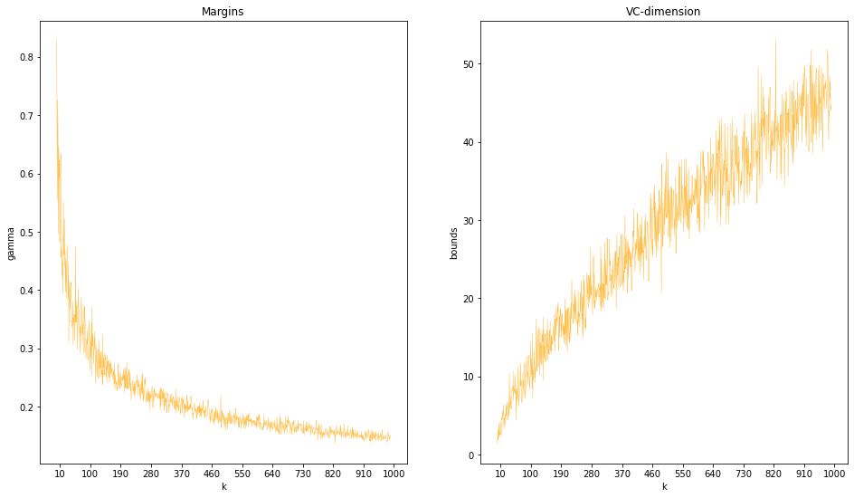

```python
bounds = 1 / marg**2

_, (ax_m, ax_b) = plt.subplots(1, 2, figsize=(16, 9))

ax_m.set_title('Margins')
ax_m.plot(marg, color='orange', alpha=0.7, linewidth=0.5)
ax_m.set_ylabel('gamma')
ax_m.set_xlabel('k')
ax_m.set_xticks(ticks=range(10, 1001, 90))

ax_b.set_title('VC-dimension')
ax_b.plot(bounds, color='orange', alpha=0.7, linewidth=0.5)
ax_b.set_ylabel('bounds')
ax_b.set_xlabel('k')
ax_b.set_xticks(ticks=range(10, 1001, 90))

plt.show()
```

It should be clearly visible from the plot, that, up to small fluctuations, the value of the margin decreases for a larger number of data points. This should come as no surprise, since the model gets increasingly complex for a larger number of data, and therefore a clearer separation is harder, which is indicated by smaller margins. Also the increase of the VC-dimension should come as a reasonable fact, since VC-dimension provides an indicator for model complexity and it indeed seems to be a reasonable concept that can provide a theoretical basis for measuring the quality of widle applied classifier algorithms.